# HLC R Class - Day 1

This creates a plotting area that is informed by the data in `iris`.

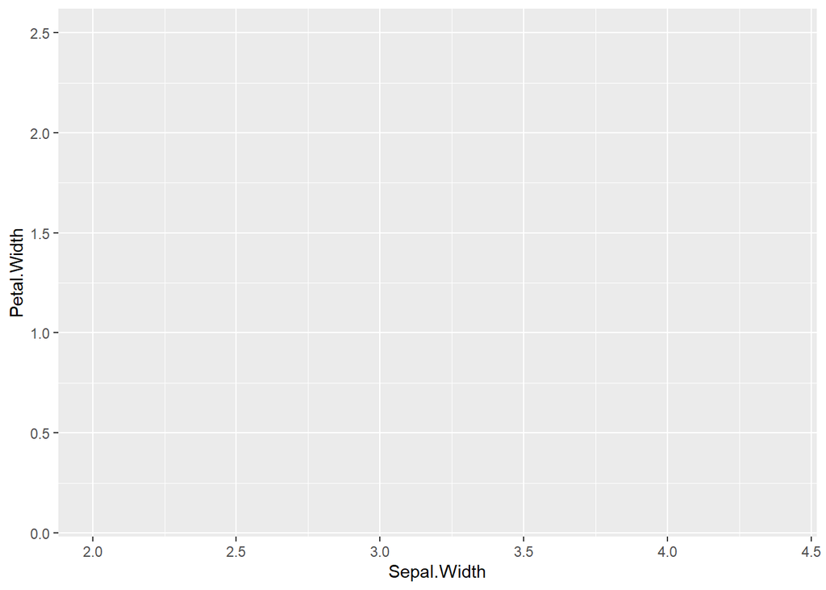

```r
ggplot(data = iris, mapping = aes(x = Sepal.Width, y = Petal.Width))
```

Now let’s add the points. We do this by adding a `geom`. In this case `geom_point` for datapoints.

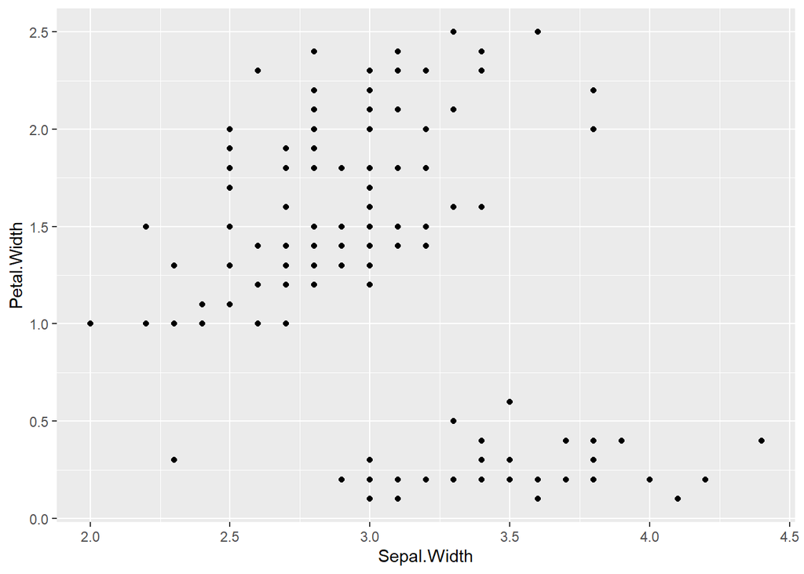

```r
ggplot(data = iris, mapping = aes(x = Sepal.Width, y = Petal.Width)) +
  geom_point()
```

Plots can be saved to variables just like before

```r
sepal.vs.petal <- ggplot(data = iris, mapping = aes(x = Sepal.Width, y = Petal.Width)) +
  geom_point()
```

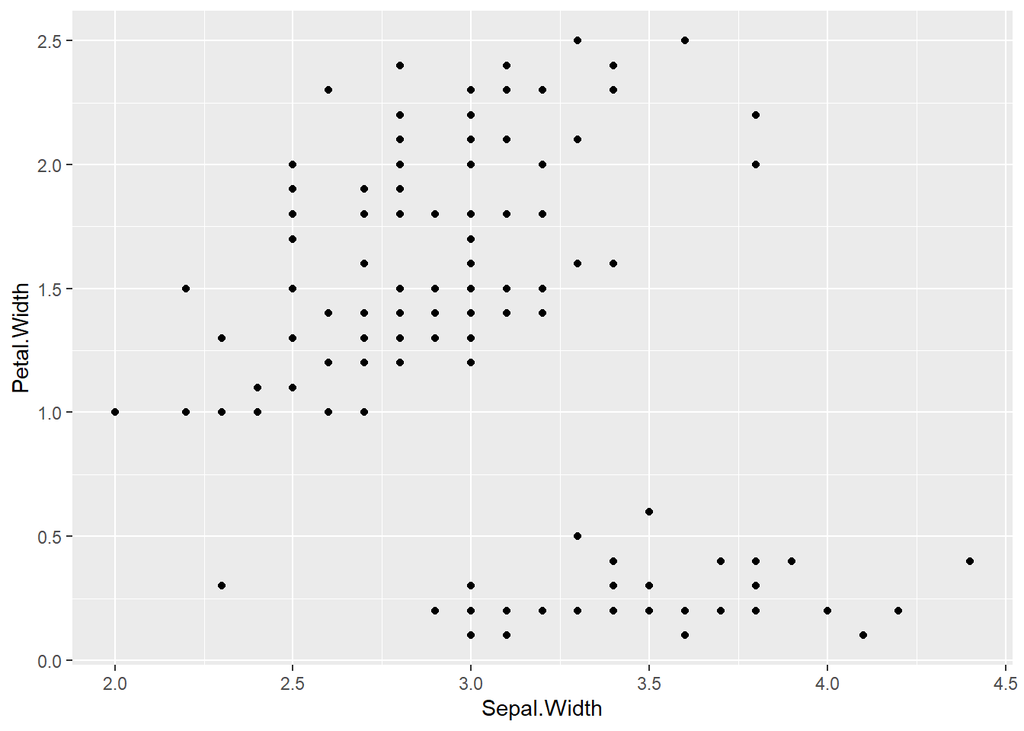

```r
sepal.vs.petal
```

We can edit the parameters of geoms. For example, you can change the color of the points by editing the `color` parameter.

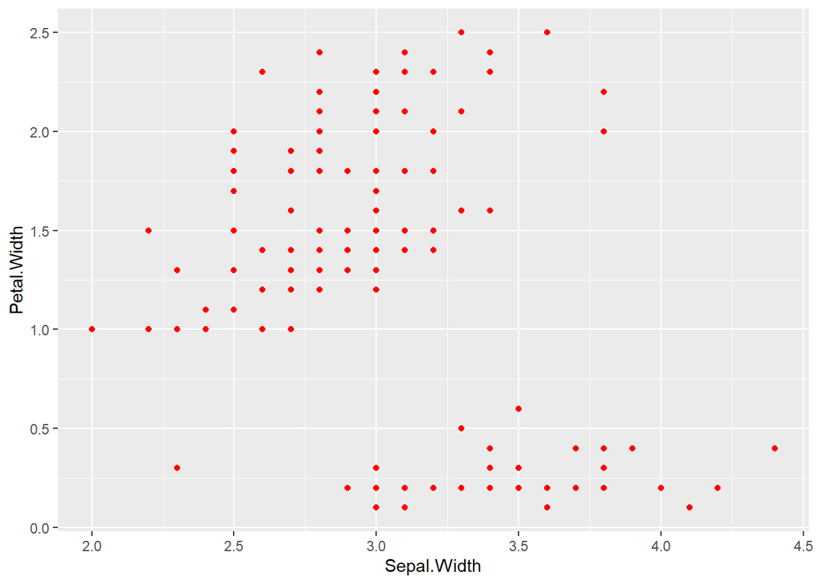

```r
ggplot(data = iris, mapping = aes(x = Sepal.Width, y = Petal.Width)) +
  geom_point(color = "red")
```

A really helpful cheatsheet detailing different aspects of ggplot can be found [here](https://www.maths.usyd.edu.au/u/UG/SM/STAT3022/r/current/Misc/data-visualization-2.1.pdf)

## Exercise:

### Question 1:

- Try making the same scatterplot but color the points by their `Species`.
- **Hints:**
- Try looking at the help page for `aes()` with `?aes`
- If this isn’t helping, try googling a solution!

## More reading

[R for Data Science: ggplot2 introduction](https://r4ds.had.co.nz/data-visualisation.html) - Great textbook!

[ggplot2 reference manual](https://ggplot2.tidyverse.org/reference/) - really useful manual with pictures!